# Text as Data Tutorial - Introduction to Neural Modeling / Deep Learning in R through Keras and Tensorflow

Advanced Text as Data: NLP, Essex Summer School in Social Science (Summer 2021)

Burt L. Monroe

In this notebook, we’ll build our first deep learning model using Keras and Tensorflow. As we did in other notebooks, we’ll again tackle sentiment classification with the IMDB review data (in this case with the 50000 review set that comes with Keras).

Be aware … I had to set the RAM for this project at the maximum allowable – 8G – and it barely fits, giving occasional memory warnings. (It also crashes in RStudio Cloud if you run *any* model fit *after* you run the final “logistic” model.)

```r
# install.packages(reticulate)
# install.packages(keras)
library(reticulate)
library(keras)
virtualenv_create("mykerasenv")
```

```
virtualenv: mykerasenv
```

```r
use_virtualenv("mykerasenv", required = TRUE)
install_keras(method="virtualenv", envname="mykerasenv")
```

```
Using virtual environment 'mykerasenv' ...
  Using cached h5py-3.3.0-cp38-cp38-manylinux_2_12_x86_64.manylinux2010_x86_64.whl (4.5 MB)
```

```
Installation complete.
```

```r
#restarts R so run these two again
use_virtualenv("mykerasenv", required = TRUE)
library(keras)
```

# Text Classification with a Deep Feedforward Network

## Load the IMDB data

We’ll work with the IMDB review dataset that comes with keras

```r
imdb <- keras::dataset_imdb(num_words = 5000)
```

[output not shown]

```r
train_data <- imdb$train$x
train_labels <- imdb$train$y
test_data <- imdb$test$x
test_labels <- imdb$test$y
```

Look at the training data (features) and labels (positive/negative).

```r
str(train_data[[1]])
```

```
 int [1:218] 1 14 22 16 43 530 973 1622 1385 65 ...
```

```r
train_labels[[1]]
```

```
[1] 1
```

```r
max(sapply(train_data, max))
```

```
[1] 4999
```

Probably a good idea to figure out how to get back to text. Decode review 1:

```r
word_index <- dataset_imdb_word_index()
reverse_word_index <- names(word_index)
names(reverse_word_index) <- word_index
decoded_review <- sapply(train_data[[1]],
                         function(index) {
                           word <- if (index >= 3)
reverse_word_index[[as.character(index - 3)]]
                           if (!is.null(word)) word else "?"
                           })
decoded_review
```

```
  [1] "?"          "this"       "film"       "was"
  [5] "just"       "brilliant"  "casting"    "location"
  [9] "scenery"    "story"      "direction"  "everyone's"
 [13] "really"     "suited"     "the"        "part"
 [17] "they"       "played"     "and"        "you"
 [21] "could"      "just"       "imagine"    "being"
 [25] "there"      "robert"     "?"          "is"
 [29] "an"         "amazing"    "actor"      "and"
 [33] "now"        "the"        "same"       "being"
 [37] "director"   "?"          "father"     "came"
 [41] "from"       "the"        "same"       "scottish"
 [45] "island"     "as"         "myself"     "so"
 [49] "i"          "loved"      "the"        "fact"
 [53] "there"      "was"        "a"          "real"
 [57] "connection" "with"       "this"       "film"
```

[output cut: 40 more lines]

## Create multi-hot vectors for input

Create “multi-hot” vectorization of input features. (Binary indicators of presence or absence of feature - in this case word / token - in the input “sequence” - in this case review.)

```r
vectorize_sequences <- function(sequences, dimension = 5000) {
  results <- matrix(0, nrow = length(sequences), ncol = dimension)
  for (i in 1:length(sequences))
    results[i, sequences[[i]]] <- 1
  results
}

x_train <- vectorize_sequences(train_data)
x_test <- vectorize_sequences(test_data)

# Also change labels from integer to numeric
y_train <- as.numeric(train_labels)
y_test <- as.numeric(test_labels)
```

## Define the model architecture.

We need a model architecture. In the case of our feedforward network, this can be built from simple layer building blocks from Keras using `keras_model_sequential`

We define three keras layers. For all of them, we use “dense” layers, meaning all every node in each layer is connected to every node in the next. For the first layer – the layer that takes the inputs – we need to specify the “input shape”, which in this case is a one-dimensional vector of length 5000. We’ll make each of our hidden layers consist of 16 nodes, with “relu” activation functions. (ReLU is generally taken to be the best default activation function for hidden layers.) Our output layer will consist of a single node, with a sigmoid (logistic) activation function outputting a probability of being positive.

```r
model <- keras_model_sequential() %>%
  layer_dense(units = 16, activation = "relu", input_shape = c(5000)) %>%
  layer_dense(units = 16, activation = "relu") %>%
  layer_dense(units = 1, activation = "sigmoid")
```

[output not shown]

```r
summary(model)
```

```
Model: "sequential"
____________________________________________________________________
Layer (type)                  Output Shape               Param #
====================================================================
dense_2 (Dense)               (None, 16)                 80016
____________________________________________________________________
dense_1 (Dense)               (None, 16)                 272
____________________________________________________________________
dense (Dense)                 (None, 1)                  17
====================================================================
Total params: 80,305
Trainable params: 80,305
Non-trainable params: 0
____________________________________________________________________
```

(This error message is related to the lack of access to GPUs. It still runs).

Note there are a few extra parameters than there are nodes. This is because of bias parameters for each node – effectively taking one extra “always on” input.

## Compile your model - Optimizer, Loss, Metrics

We need to “compile” our model by adding information about our loss function, what optimizer we wish to use, and what metrics we want to keep track of. The “adam” optimizer is generally taken to be the default, but you might wish to try others. We’ll use a binary cross-entropy loss function, which is exactly the same as the logit loss function from GLMs. We also tell it what performance metrics to track.

```r
model %>% compile(
  optimizer = "adam",
  loss = "binary_crossentropy",
  metrics = c("accuracy")
)
```

## Create validation data

Create a held-out set of your training data for validation.

```r
val_indices <- 1:10000 # not great practice if these are ordered

x_val <- x_train[val_indices,]
partial_x_train <- x_train[-val_indices,]
y_val <- y_train[val_indices]
partial_y_train <- y_train[-val_indices]
```

## Fit the model

Fit the model, store the fit history.

```r
history <- model %>% fit(
  partial_x_train,
  partial_y_train,
  epochs = 20,
  batch_size = 512,
  validation_data = list(x_val, y_val)
)
```

```
2021-07-29 06:57:17.691981: I tensorflow/compiler/mlir/mlir_graph_optimization_pass.cc:176] None of the MLIR Optimization Passes are enabled (registered 2)
2021-07-29 06:57:17.714681: I tensorflow/core/platform/profile_utils/cpu_utils.cc:114] CPU Frequency: 2999995000 Hz
```

```r
str(history)
```

```
List of 2
 $ params :List of 3
  ..$ verbose: int 1
  ..$ epochs : int 20
  ..$ steps  : int 30
 $ metrics:List of 4
  ..$ loss        : num [1:20] 0.577 0.34 0.25 0.205 0.176 ...
  ..$ accuracy    : num [1:20] 0.752 0.885 0.911 0.928 0.939 ...
  ..$ val_loss    : num [1:20] 0.434 0.321 0.292 0.289 0.294 ...
  ..$ val_accuracy: num [1:20] 0.848 0.875 0.883 0.885 0.879 ...
 - attr(*, "class")= chr "keras_training_history"
```

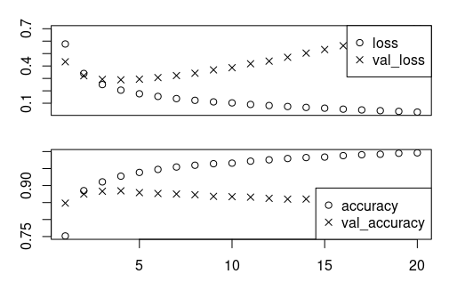

```r
plot(history)
```

## Address overfitting

Overfitting. It basically memorized the training data. There are a number of things we can do, including regularizing weights and dropout, which we’ll discuss later. For now, we can (manually) do “early stopping” by fitting at a smaller number of epochs.

```r
model <- keras_model_sequential() %>%
  layer_dense(units = 16, activation = "relu", input_shape = c(5000)) %>%
  layer_dense(units = 16, activation = "relu") %>%
  layer_dense(units = 1, activation = "sigmoid")

model %>% compile(
  optimizer = "adam",
  loss = "binary_crossentropy",
  metrics = c("accuracy")
)

model %>% fit(x_train, y_train, epochs = 4, batch_size = 512)
results <- model %>% evaluate(x_test, y_test)
```

## Interpretation

So, what happened there? What is the model learning? It learned a function that converts 5000 inputs into 16 hidden / latent / intermediate numbers, then converts those 16 into a different 16 intermediate numbers, and then those into 1 number at the output. Those intermediate functions are nonlinear, otherwise there wouldn’t be any gain from stacking them together. But we can get an approximate idea of how these inputs map to the single output by treating each layer as linear and multiplying the weights through: $W^{(5000\times 1)}_{io} \approx W_{i1}^{(5000\times 16)} \times W_{12}^{(16\times 16)} \times W_{2o}^{(16\times 1)}$. Those aggregate weights can give us an approximate idea of the main marginal effect of each input. (This ignores the bias weights at each layer, and the rectified/zeroed out part of the relu activation functions. This will not work, generally speaking, in more complex models or contexts.)

```r
model.weights.approx <- (get_weights(model)[[1]] %*% get_weights(model)[[3]]  %*% get_weights(model)[[5]])[,1]
top_words <- reverse_word_index[as.character(1:5000)]
names(model.weights.approx) <- c("<PAD>","<START>","<UNK>",top_words[1:4997])

sort(model.weights.approx, dec=T)[1:20]
```

```
          7   excellent           8 wonderfully  refreshing
  1.1771226   1.0506569   0.9884224   0.9761549   0.9744723
    perfect        rare         gem        edie    flawless
  0.9631055   0.9206588   0.9149824   0.8882311   0.8866553
       noir appreciated    funniest    captures       loved
  0.8727235   0.8687327   0.8277789   0.8188553   0.8149409
 incredible     amazing      superb    superbly      hooked
  0.8143795   0.8029910   0.7928865   0.7825648   0.7811740
```

```r
sort(model.weights.approx, dec=F)[1:20]
```

```
disappointment          worst          waste          awful
    -1.2690208     -1.2117737     -1.1439835     -1.0575347
        poorly  disappointing    forgettable     incoherent
    -1.0374718     -0.9759874     -0.9675105     -0.9336939
     redeeming          lousy          mst3k           dull
    -0.9294352     -0.9266108     -0.9248852     -0.9170705
        boring          avoid        unfunny           mess
    -0.8982002     -0.8816448     -0.8811086     -0.8768368
   unwatchable      laughable      obnoxious      pointless
    -0.8742200     -0.8690024     -0.8594846     -0.8537718
```

“7” is interesting. It comes from reviews like #168, which ends like this:

```r
sapply(train_data[[168]],function(index) {
  word <- if (index >= 3) reverse_word_index[[as.character(index - 3)]]
  if (!is.null(word)) word
  else "?"})[201:215]
```

```
 [1] "creates"    "a"          "great"      "monster"
 [5] "like"       "atmosphere" "br"         "br"
 [9] "vote"       "7"          "and"        "half"
[13] "out"        "of"         "10"
```

That means the entire ecosystem of imdb-data-sentiment-classifiers (thousands of examples) are solving a much easier problem than it superficially appears to be. Some of the reviews end with the text summarizing the rating with a number out of 10! And then use that to “predict” whether the review is positive or negative (which has been labeled based on the 10 point scale rating in the first place).

And we can look at these similarly to how we looked at the coefficients from the classifiers in our earlier notebook. I’ll also highlight those numbers.

```r
colnames(x_train) <- names(model.weights.approx)
# Plot weights
plot(colSums(x_train),model.weights.approx, pch=19, col=rgb(0,0,0,.3), cex=.5, log="x", main="Weights Learned in Deep Model, IMDB", ylab="<--- Negative Reviews --- Positive Reviews --->", xlab="Total Appearances")
text(colSums(x_train),model.weights.approx, names(model.weights.approx),pos=4,cex=1.5*abs(model.weights.approx), col=rgb(0,0,0,.5*abs(model.weights.approx)))
```

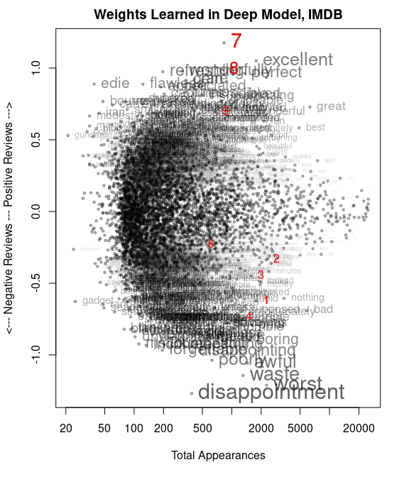

```r
text(colSums(x_train[,c("1","2","3","4","5","6","7","8","9")]),model.weights.approx[c("1","2","3","4","5","6","7","8","9")], names(model.weights.approx[c("1","2","3","4","5","6","7","8","9")]),pos=4,cex=1.5*model.weights.approx[c("1","2","3","4","5","6","7","8","9")], col=rgb(1,0,0,1))
```

# Compare to perceptron / shallow model

It’s worth pointing out that “deep” didn’t buy us much of anything. If we just estimate with a single sigmoid (logistic) layer, we get nearly identical results that are very close.

```r
logistic.mod <- keras_model_sequential() %>%
  layer_dense(units = 1, activation = "sigmoid", input_shape = c(5000))

summary(logistic.mod)
```

```
Model: "sequential_2"
____________________________________________________________________
Layer (type)                  Output Shape               Param #
====================================================================
dense_6 (Dense)               (None, 1)                  5001
====================================================================
Total params: 5,001
Trainable params: 5,001
Non-trainable params: 0
____________________________________________________________________
```

5000 parameters rather than 80000.

I’ve had some unexplained crashes at this point. If the following is run, it completes, but then the Rstudio Cloud session crashes if you run anything else. So I’ll just skip to the “early stopping” number of epochs, 35, copy the results and then comment out this chunk.

```r
# logistic.mod %>% compile(
#   optimizer = "adam",
#   loss = "binary_crossentropy",
#   metrics = c("accuracy")
# )
#
# history <- logistic.mod %>% fit(
#   partial_x_train,
#   partial_y_train,
#   epochs = 35,
#   batch_size = 512,
#   validation_data = list(x_val, y_val)
# )
```

> Epoch 1/35 30/30 [==============================] - 1s 11ms/step - loss: 0.6412 - accuracy: 0.6749 - val_loss: 0.5893 - val_accuracy: 0.7767 Epoch 2/35 30/30 [==============================] - 0s 4ms/step - loss: 0.5457 - accuracy: 0.8129 - val_loss: 0.5227 - val_accuracy: 0.8179 Epoch 3/35 30/30 [==============================] - 0s 4ms/step - loss: 0.4854 - accuracy: 0.8445 - val_loss: 0.4783 - val_accuracy: 0.8376 Epoch 4/35 30/30 [==============================] - 0s 4ms/step - loss: 0.4432 - accuracy: 0.8619 - val_loss: 0.4466 - val_accuracy: 0.8481 Epoch 5/35 30/30 [==============================] - 0s 3ms/step - loss: 0.4116 - accuracy: 0.8734 - val_loss: 0.4224 - val_accuracy: 0.8534 Epoch 6/35 30/30 [==============================] - 0s 3ms/step - loss: 0.3861 - accuracy: 0.8816 - val_loss: 0.4024 - val_accuracy: 0.8614 Epoch 7/35 30/30 [==============================] - 0s 4ms/step - loss: 0.3653 - accuracy: 0.8886 - val_loss: 0.3868 - val_accuracy: 0.8650 Epoch 8/35 30/30 [==============================] - 0s 4ms/step - loss: 0.3481 - accuracy: 0.8931 - val_loss: 0.3747 - val_accuracy: 0.8669 Epoch 9/35 30/30 [==============================] - 0s 3ms/step - loss: 0.3337 - accuracy: 0.8978 - val_loss: 0.3640 - val_accuracy: 0.8697 Epoch 10/35 30/30 [==============================] - 0s 3ms/step - loss: 0.3210 - accuracy: 0.9011 - val_loss: 0.3553 - val_accuracy: 0.8720 Epoch 11/35 30/30 [==============================] - 0s 3ms/step - loss: 0.3099 - accuracy: 0.9038 - val_loss: 0.3467 - val_accuracy: 0.8750 Epoch 12/35 30/30 [==============================] - 0s 3ms/step - loss: 0.2998 - accuracy: 0.9081 - val_loss: 0.3402 - val_accuracy: 0.8744 Epoch 13/35 30/30 [==============================] - 0s 4ms/step - loss: 0.2909 - accuracy: 0.9093 - val_loss: 0.3342 - val_accuracy: 0.8782 Epoch 14/35 30/30 [==============================] - 0s 4ms/step - loss: 0.2830 - accuracy: 0.9121 - val_loss: 0.3295 - val_accuracy: 0.8789 Epoch 15/35 30/30 [==============================] - 0s 3ms/step - loss: 0.2758 - accuracy: 0.9143 - val_loss: 0.3247 - val_accuracy: 0.8788 Epoch 16/35 30/30 [==============================] - 0s 3ms/step - loss: 0.2689 - accuracy: 0.9175 - val_loss: 0.3205 - val_accuracy: 0.8802 Epoch 17/35 30/30 [==============================] - 0s 3ms/step - loss: 0.2627 - accuracy: 0.9181 - val_loss: 0.3172 - val_accuracy: 0.8813 Epoch 18/35 30/30 [==============================] - 0s 3ms/step - loss: 0.2570 - accuracy: 0.9197 - val_loss: 0.3141 - val_accuracy: 0.8814 Epoch 19/35 30/30 [==============================] - 0s 4ms/step - loss: 0.2516 - accuracy: 0.9222 - val_loss: 0.3113 - val_accuracy: 0.8828 Epoch 20/35 30/30 [==============================] - 0s 4ms/step - loss: 0.2468 - accuracy: 0.9225 - val_loss: 0.3086 - val_accuracy: 0.8825 Epoch 21/35 30/30 [==============================] - 0s 4ms/step - loss: 0.2421 - accuracy: 0.9242 - val_loss: 0.3065 - val_accuracy: 0.8833 Epoch 22/35 30/30 [==============================] - 0s 3ms/step - loss: 0.2376 - accuracy: 0.9271 - val_loss: 0.3044 - val_accuracy: 0.8834 Epoch 23/35 30/30 [==============================] - 0s 3ms/step - loss: 0.2336 - accuracy: 0.9264 - val_loss: 0.3029 - val_accuracy: 0.8833 Epoch 24/35 30/30 [==============================] - 0s 4ms/step - loss: 0.2297 - accuracy: 0.9286 - val_loss: 0.3011 - val_accuracy: 0.8829 Epoch 25/35 30/30 [==============================] - 0s 4ms/step - loss: 0.2259 - accuracy: 0.9299 - val_loss: 0.2995 - val_accuracy: 0.8832 Epoch 26/35 30/30 [==============================] - 0s 3ms/step - loss: 0.2225 - accuracy: 0.9313 - val_loss: 0.2985 - val_accuracy: 0.8835 Epoch 27/35 30/30 [==============================] - 0s 4ms/step - loss: 0.2191 - accuracy: 0.9319 - val_loss: 0.2971 - val_accuracy: 0.8827 Epoch 28/35 30/30 [==============================] - 0s 4ms/step - loss: 0.2159 - accuracy: 0.9327 - val_loss: 0.2960 - val_accuracy: 0.8834 Epoch 29/35 30/30 [==============================] - 0s 4ms/step - loss: 0.2128 - accuracy: 0.9336 - val_loss: 0.2952 - val_accuracy: 0.8834 Epoch 30/35 30/30 [==============================] - 0s 4ms/step - loss: 0.2099 - accuracy: 0.9347 - val_loss: 0.2942 - val_accuracy: 0.8833 Epoch 31/35 30/30 [==============================] - 0s 3ms/step - loss: 0.2072 - accuracy: 0.9357 - val_loss: 0.2936 - val_accuracy: 0.8825 Epoch 32/35 30/30 [==============================] - 0s 3ms/step - loss: 0.2046 - accuracy: 0.9361 - val_loss: 0.2929 - val_accuracy: 0.8828 Epoch 33/35 30/30 [==============================] - 0s 3ms/step - loss: 0.2020 - accuracy: 0.9384 - val_loss: 0.2922 - val_accuracy: 0.8832 Epoch 34/35 30/30 [==============================] - 0s 4ms/step - loss: 0.1995 - accuracy: 0.9391 - val_loss: 0.2917 - val_accuracy: 0.8826 Epoch 35/35 30/30 [==============================] - 0s 3ms/step - loss: 0.1970 - accuracy: 0.9391 - val_loss: 0.2913 - val_accuracy: 0.8831

```r
#results <- logistic.mod %>% evaluate(x_test, y_test)
```

> 782/782 [==============================] - 0s 589us/step - loss: 0.3021 - accuracy: 0.8771

So, nearly the same results and a directly interpretable single layer of weights:

```r
word.weights <- get_weights(logistic.mod)[[1]]
top_words <- reverse_word_index[as.character(1:5000)]
names(word.weights) <- c("<PAD>","<START>","<UNK>",top_words[1:4997])

sort(word.weights, dec=T)[1:20]
```

```
          7 appreciated   excellent       great           8
  0.6383946   0.5248996   0.5182908   0.5069323   0.5050004
 incredible    funniest     perfect        iran         gem
  0.4989627   0.4893020   0.4815048   0.4766634   0.4754367
      loved  refreshing    haunting           9 wonderfully
  0.4709021   0.4702339   0.4628750   0.4611071   0.4590441
  enjoyable        rare       tight    flawless   wonderful
  0.4588302   0.4500180   0.4403109   0.4363520   0.4358278
```

```r
sort(word.weights, dec=F)[1:20]
```

```
disappointment          worst          lacks         boring
    -0.5926315     -0.5545152     -0.5462594     -0.5387052
 disappointing        unfunny          waste           mess
    -0.5318602     -0.5178436     -0.5171169     -0.5167639
   forgettable      laughable         poorly     incoherent
    -0.5131137     -0.4964658     -0.4950798     -0.4942107
         awful          fails         wooden    unwatchable
    -0.4922123     -0.4850956     -0.4781687     -0.4775044
          dull          lousy      redeeming           flop
    -0.4758189     -0.4741764     -0.4735830     -0.4702056
```

```r
cor(model.weights.approx, word.weights)
```

```
          [,1]
[1,] 0.8757551
```

The weights are correlated highly with the approximate net weights found before.

So, we successfully built a deep feedforward network for text classification, but it showed only minimal improvement over a simpler model. In subsequent notebooks, we’ll see if we can improve through other changes.

## Practice Exercise:

1. See if you can improve performance through changes in the architecture (number of layers, number of nodes, activation functions - https://keras.io/api/layers/activations/) or training options (optimizer - see https://keras.io/api/optimizers/, or loss function - https://keras.io/api/losses/)
2. Why is the current model overfitting?